# Figure Skating Two-Way ANOVA Solutions

Figure skating is a sport where people perform routines on ice to music, combining athletic skill with artistic expression. Skaters compete in different categories like men’s singles, women’s singles, pairs (a man and a woman skating together), and ice dance (which focuses more on rhythm and movement). Each skater or team performs two routines: the short program and the free skate. The short program is a shorter routine with a list of required moves that every skater must include. Judges look at how well each move is done and how smoothly everything fits with the music. The free skate is longer and gives skaters more freedom to show their personal style and creativity. They still need to include certain types of moves, but they can choose how to put them together. Judges give scores for both routines based on how difficult the moves are, how well they’re done, and how artistic the performance is. The scores from both routines are added together, and the skater or team with the highest total wins.

Read in the data:

```r
library(ggplot2)
library(tidyverse)
library(here)
library(readr)
library(dplyr)
library(ggthemes)

MensFigureSkating <- read_csv("C:/Users/0211f/GitHub/slu_score_module_development/frhinehart/Olympic Figure Skating/TwoWayAnova/Module/MensFigureSkating.csv")

womensFigureSkating <- read_csv("C:/Users/0211f/GitHub/slu_score_module_development/frhinehart/Olympic Figure Skating/TwoWayAnova/Module/womensFigureSkating.csv")
```

```r
womensFigureSkating$TP <- as.double(womensFigureSkating$TP)
```

2. Add a `Sex` variable in the MensFigureSkating dataset that indicates male.

```r
MensFigureSkating$Sex <- "Male"
```

3. Combine the men and women data set into one data set

```r
combined_Skate <- bind_rows(womensFigureSkating, MensFigureSkating)
View(combined_Skate)
```

4. Conduct a two-way ANOVA with Sex as the interaction term. Make sure to include all parts of a formal hypothesis test.

Main Effects: H₀₁ (Sex): There is no main effect of Sex on TP. H₀₂ (Category): There is no main effect of Year on TP.

Interaction Effect: H₀₃ (Sex × Category): There is no interaction effect between Sex and Year on TP.

Alternative Hypotheses: There is an effect between the variables.

```r
anova_result <- aov(TP ~ as.factor(Year) * Sex, data = combined_Skate)
summary(anova_result)
```

```
                     Df Sum Sq Mean Sq F value Pr(>F)
as.factor(Year)       4 103933   25983  31.932 <2e-16 ***
Sex                   1 191457  191457 235.289 <2e-16 ***
as.factor(Year):Sex   4   6342    1585   1.948  0.103
Residuals           229 186340     814
---
Signif. codes:  0 '***' 0.001 '**' 0.01 '*' 0.05 '.' 0.1 ' ' 1
1 observation deleted due to missingness
```

5. Create a boxplot that models this interaction with `Sex` on the x-axis, `TP` on the y-axis, and fill by `Year`. (You will have to change `Year` to a factor). Comment on what you notice.

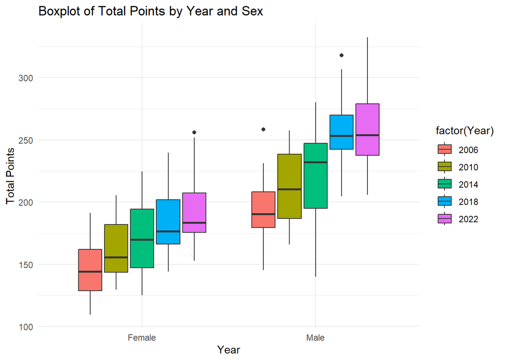

```r
ggplot(combined_Skate, aes(x = Sex, y = TP, fill = factor(Year))) +
  geom_boxplot() +
  labs(title = "Boxplot of Total Points by Year and Sex",
       x = "Year",
       y = "Total Points") +
  theme_minimal()
```

Females tend to increases by steps whereas for males it increase unevenly.

6. Conduct another two-way ANOVA with `Sex` as a additive term. Make sure to include all parts of a formal hypothesis test.

Main Effects: H₀₁ (Sex): There is no main effect of Sex on TP. H₀₂ (Category): There is no main effect of Year on TP.

Alternative Hypotheses: There is an effect between the variables.

```r
anova_result2 <- aov(TP ~ as.factor(Year) + Sex, data = combined_Skate)
summary(anova_result2)
```

```
                 Df Sum Sq Mean Sq F value Pr(>F)
as.factor(Year)   4 103933   25983   31.42 <2e-16 ***
Sex               1 191457  191457  231.52 <2e-16 ***
Residuals       233 192681     827
---
Signif. codes:  0 '***' 0.001 '**' 0.01 '*' 0.05 '.' 0.1 ' ' 1
1 observation deleted due to missingness
```

```r
tukey_result2 <- TukeyHSD(anova_result2)
tukey_result2
```

```
  Tukey multiple comparisons of means
    95% family-wise confidence level

Fit: aov(formula = TP ~ as.factor(Year) + Sex, data = combined_Skate)

$`as.factor(Year)`
               diff         lwr      upr     p adj
2010-2006 16.356028   0.1323323 32.57972 0.0470752
2014-2006 25.745625   9.6075427 41.88371 0.0001691
2018-2006 51.090208  34.9521260 67.22829 0.0000000
2022-2006 54.912292  38.7742093 71.05037 0.0000000
2014-2010  9.389597  -6.8340995 25.61329 0.5045565
2018-2010 34.734180  18.5104838 50.95788 0.0000001
2022-2010 38.556263  22.3325672 54.77996 0.0000000
2018-2014 25.344583   9.2065010 41.48267 0.0002248
2022-2014 29.166667  13.0285843 45.30475 0.0000129
2022-2018  3.822083 -12.3159990 19.96017 0.9663011

$Sex
                diff      lwr      upr p adj
Male-Female 56.60501 49.27531 63.93472     0
```

Significant: 2010-2006 2014-2006 2018-2006 2022-2006 2018-2010 2022-2010 2018-2014 2022-2014

Not Significant: 2014-2010 2022-2018

The sex variable is significant: $Sex diff lwr upr p adj Male-Female 56.60501 49.27531 63.93472 0

9. If you completed the one-way ANOVA module and did the optional pair wise comparisons, comment on how and why this two-way ANOVA letter’s table is different from the one you did in the other one.